# GitHub Pages Tutorial

Krista Dulany

2022-09-02

[figure not shown]

The purpose of this document is to serve as a guide and a reference to develop a R Markdown document into an HTML format to host online using GitHub Pages.

# 1 Introduction to Git Hub

## 1.1 Git, GitHub, and R Studio

This information is provided by the LASER institute

**Git**

- A version control system
- Tracks history of changes for individuals or collaborative teams
- Git repositories (or projects) encompass all files and folders associated with a project along with each files revision history

**GitHub**

- a web-based platform that hosts Git repositories
- provides a collaborative, community-based development environment
- provides an extensive ecosystem for software workflows

**GitHub Desktop**

- A way to interface with Git repositories and files local on your computer

**R Studio**

- Interface to write script and R markdown files
- Can develop programs to analyze data
- Use to create R Markdown documents to host webpages

**R Markdown**

## 1.2 GitHub Getting Started

### 1.2.1 Github Profile

Go to the EQuIPD GitHub page: https://github.com/UF-EQuIPDGrant

[figure not shown]

Repositories shows all the repositories that the person or organization has created or forked (made a personal copy from another source). We will talk about cloning and forking in a moment. For this tutorial we will be using **GitHub_Pages_Tutorial** repository. https://github.com/UF-EQuIPDGrant/GitHub_Pages_Tutorial

[figure not shown]

### 1.2.2 Creating a New Repository

We will briefly walk through creating a new repository. This is the process you would take when you wanted to start a new project to analyze data or create a GitHub page on your own.

[figure not shown]

[figure not shown]

### 1.2.3 Forking Versus Cloning

**For this session,** we will be using the **GitHub_Pages_Tutorial** repository as a base. You will now go through the process of creating your own copy of the repository to work in. This is helpful when you have found a resource or are working with a team on a project in GitHub.

There is an important distinction between cloning a repository and forking a repository.You need to think about how you are working the owner of the repository.

**Cloning** is the act of creating a linked version of the repository local to your account and computer through GitHub desktop. This option is great if you are collaborating with a team to develop something together. The main version is updated by the group.

[figure not shown]

**Forking** is the act of creating your own copy that is not linked to others. This is a great option when you are wanting to modify a repository or project that you found online or if you are working together but not needing to keep a single version. Information and updates from the original will still update from the original source. *In our case we will be Forking our repository so everyone has their own version and we do not overwrite each other.*

[figure not shown]

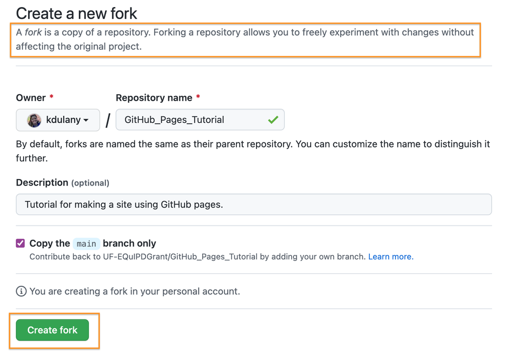

Once you create your forked repository we then move to GitHub Desktop

### 1.2.4 GitHub Desktop

GitHub desktop is the interface between R Studio and GitHub. When updates are made by the host of the repository or updates are made by you, the changes are documented and shown in GitHub desktop. History provides information on who, when, and what was updated. This is part of the version control. If your repository is forked then the only updates are coming from the main page and you. If you have a cloned repository, you will see updates from your collaborators.

Use Fetch/Pull to get new information from the main server. Use Commit to update or Push your changes to the repository. You must enter a small description to be able to commit the changes. You will then be prompted to Push that information. You will see the updates online on GitHub.

Use open in RStudio to open the project in an editor workspace or use Show in Finder toview the documents in this repository.

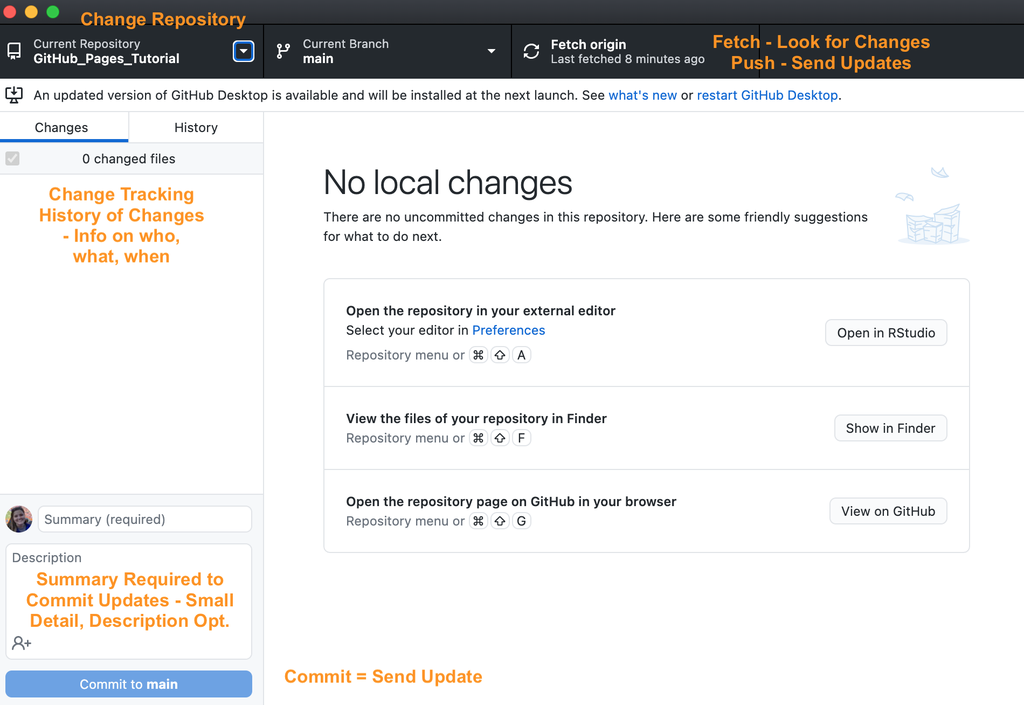

When you drop down the selection tool to navigate between repositories, there should be a forked symbol next to the GitHub Pages Tutorial repository. A book symbol notifies that a repository is a clone.

[figure not shown]

Let’s move into the basics of R Markdown.

# 2 R Markdown Formatting

First thing we are going to do is “knit” this document using the knit button at the top of the window. Knitting is rendering the R Markdown file into the designated form. In our case, we are using R Markdown to create an html document. You can use this to create word documents, presentations, pdf, and more.

We will then see this document in a preview window and we are then going to select “Open in Browser” to view the HTML document in a browser window. This will be a reference for us as we move through the document to see what the R Markdown code and formatting looks like in its final form.

## 2.1 YAML Header

The first part of an R Markdown page is the YAML header. This is where you title the page, add an author, set the date, and choose a file type to process into.

## 2.2 Output

Output is how you set the type of document that is exported. This is also where you can add features like styles, tables of contents, and figure dimensions

**More Formatting References** https://rmarkdown.rstudio.com/authoring_basics.html https://bookdown.org/yihui/rmarkdown/html-document.html

## 2.3 Image Insert

### 2.3.1 Code Chunks

Code Chunks are used to run code to complete an analysis. If you want to create a document that steps students through a programming activity, you could use something like this.

To insert a code chunk, go to Code> Insert Chunk or use the following shortcuts depending on your device: Ctrl + Alt + I (Cmd + Option + I on macOS).

```r
#install.packages("readxl")
#install.packages("knitr")
#install.packages("tidyverse")

#library(readxl)
#library(knitr)
#library(tidyverse)
```

# 3 Publishing to GitHub Pages

Knit Commit Go to GitHub Online

Click repository name Settings Public Main Branch